# Risk Factor Analysis

## Outcome Variable

**Outcome Variable:** whz

## Predictor Variables

**Intervention Variable:** fage

**Adjustment Set:**

- arm
- W_mage
- meducyrs
- feducyrs
- W_mhtcm
- W_mwtkg
- W_mbmi
- W_fhtcm
- single
- brthmon
- delta_W_mage
- delta_meducyrs
- delta_feducyrs
- delta_W_mhtcm
- delta_W_mwtkg
- delta_W_mbmi
- delta_W_fhtcm
- delta_single
- delta_brthmon

## Stratifying Variables

The analysis was stratified on these variable(s):

- agecat
- studyid
- country

## Data Summary

| agecat | studyid | country | fage | n_cell | n | outcome_variable |
| --- | --- | --- | --- | --- | --- | --- |
| Birth | COHORTS | GUATEMALA | >=38 | 222 | 735 | whz |
| Birth | COHORTS | GUATEMALA | <32 | 337 | 735 | whz |
| Birth | COHORTS | GUATEMALA | [32-38) | 176 | 735 | whz |
| Birth | COHORTS | PHILIPPINES | >=38 | 303 | 2797 | whz |
| Birth | COHORTS | PHILIPPINES | <32 | 1981 | 2797 | whz |
| Birth | COHORTS | PHILIPPINES | [32-38) | 513 | 2797 | whz |
| Birth | MAL-ED | BANGLADESH | >=38 | 61 | 128 | whz |
| Birth | MAL-ED | BANGLADESH | <32 | 23 | 128 | whz |
| Birth | MAL-ED | BANGLADESH | [32-38) | 44 | 128 | whz |
| Birth | MAL-ED | BRAZIL | >=38 | 5 | 16 | whz |
| Birth | MAL-ED | BRAZIL | <32 | 1 | 16 | whz |
| Birth | MAL-ED | BRAZIL | [32-38) | 10 | 16 | whz |
| Birth | MAL-ED | INDIA | >=38 | 7 | 25 | whz |
| Birth | MAL-ED | INDIA | <32 | 8 | 25 | whz |
| Birth | MAL-ED | INDIA | [32-38) | 10 | 25 | whz |
| Birth | MAL-ED | NEPAL | >=38 | 2 | 9 | whz |
| Birth | MAL-ED | NEPAL | <32 | 2 | 9 | whz |
| Birth | MAL-ED | NEPAL | [32-38) | 5 | 9 | whz |
| Birth | MAL-ED | PERU | >=38 | 23 | 67 | whz |
| Birth | MAL-ED | PERU | <32 | 21 | 67 | whz |
| Birth | MAL-ED | PERU | [32-38) | 23 | 67 | whz |
| Birth | MAL-ED | SOUTH AFRICA | >=38 | 16 | 30 | whz |
| Birth | MAL-ED | SOUTH AFRICA | <32 | 5 | 30 | whz |
| Birth | MAL-ED | SOUTH AFRICA | [32-38) | 9 | 30 | whz |
| Birth | MAL-ED | TANZANIA, UNITED REPUBLIC OF | >=38 | 17 | 44 | whz |
| Birth | MAL-ED | TANZANIA, UNITED REPUBLIC OF | <32 | 9 | 44 | whz |
| Birth | MAL-ED | TANZANIA, UNITED REPUBLIC OF | [32-38) | 18 | 44 | whz |
| Birth | PROBIT | BELARUS | >=38 | 604 | 13325 | whz |
| Birth | PROBIT | BELARUS | <32 | 10671 | 13325 | whz |
| Birth | PROBIT | BELARUS | [32-38) | 2050 | 13325 | whz |

[output cut: 75 more lines]

The following strata were considered:

- agecat: 24 months, studyid: COHORTS, country: GUATEMALA
- agecat: 24 months, studyid: COHORTS, country: PHILIPPINES
- agecat: 24 months, studyid: LCNI-5, country: MALAWI
- agecat: 24 months, studyid: MAL-ED, country: BANGLADESH
- agecat: 24 months, studyid: MAL-ED, country: BRAZIL
- agecat: 24 months, studyid: MAL-ED, country: INDIA
- agecat: 24 months, studyid: MAL-ED, country: NEPAL
- agecat: 24 months, studyid: MAL-ED, country: PERU
- agecat: 24 months, studyid: MAL-ED, country: SOUTH AFRICA
- agecat: 24 months, studyid: MAL-ED, country: TANZANIA, UNITED REPUBLIC OF
- agecat: 24 months, studyid: PROBIT, country: BELARUS
- agecat: 6 months, studyid: COHORTS, country: GUATEMALA
- agecat: 6 months, studyid: COHORTS, country: PHILIPPINES
- agecat: 6 months, studyid: LCNI-5, country: MALAWI
- agecat: 6 months, studyid: MAL-ED, country: BANGLADESH
- agecat: 6 months, studyid: MAL-ED, country: BRAZIL
- agecat: 6 months, studyid: MAL-ED, country: INDIA
- agecat: 6 months, studyid: MAL-ED, country: NEPAL
- agecat: 6 months, studyid: MAL-ED, country: PERU
- agecat: 6 months, studyid: MAL-ED, country: SOUTH AFRICA
- agecat: 6 months, studyid: MAL-ED, country: TANZANIA, UNITED REPUBLIC OF
- agecat: 6 months, studyid: PROBIT, country: BELARUS
- agecat: 6 months, studyid: SAS-CompFeed, country: INDIA
- agecat: 6 months, studyid: SAS-FoodSuppl, country: INDIA
- agecat: Birth, studyid: COHORTS, country: GUATEMALA
- agecat: Birth, studyid: COHORTS, country: PHILIPPINES
- agecat: Birth, studyid: MAL-ED, country: BANGLADESH
- agecat: Birth, studyid: MAL-ED, country: BRAZIL
- agecat: Birth, studyid: MAL-ED, country: INDIA
- agecat: Birth, studyid: MAL-ED, country: NEPAL
- agecat: Birth, studyid: MAL-ED, country: PERU
- agecat: Birth, studyid: MAL-ED, country: SOUTH AFRICA
- agecat: Birth, studyid: MAL-ED, country: TANZANIA, UNITED REPUBLIC OF
- agecat: Birth, studyid: PROBIT, country: BELARUS
- agecat: Birth, studyid: SAS-CompFeed, country: INDIA

### Dropped Strata

Some strata were dropped due to rare outcomes:

- agecat: Birth, studyid: MAL-ED, country: BRAZIL
- agecat: Birth, studyid: MAL-ED, country: NEPAL

## Methods Detail

We’re interested in the causal parameters $E[Y_a]$ for all values of $a \in \mathcal{A}$. These parameters represent the mean outcome if, possibly contrary to fact, we intervened to set all units to have $A=a$. Under the randomization and positivity assumptions, these are identified by the statistical parameters $\psi_a=E_W[E_{Y|A,W}(Y|A=a,W)]$. In addition, we’re interested in the mean of $Y$, $E[Y]$ under no intervention (the observed mean). We will estimate these parameters by using SuperLearner to fit the relevant likelihood factors – $E_{Y|A,W}(Y|A=a,W)$ and $p(A=a|W)$, and then updating our likelihood fit using a joint TMLE.

For unadjusted analyses ($W=\{\}$), initial likelihoods were estimated using Lrnr_glm to estimate the simple $E(Y|A)$ and Lrnr_mean to estimate $p(A)$. For adjusted analyses, a small library containing Lrnr_glmnet, Lrnr_xgboost, and Lrnr_mean was used.

Having estimated these parameters, we will then use the delta method to estimate relative risks and attributable risks relative to a prespecified baseline level of $A$.

# Results Detail

## Results Plots

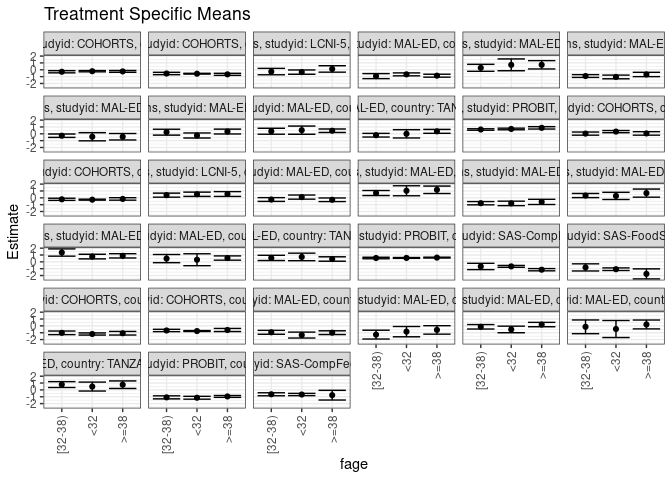

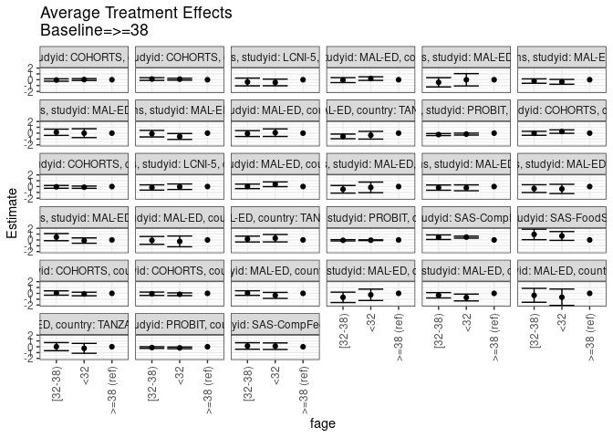

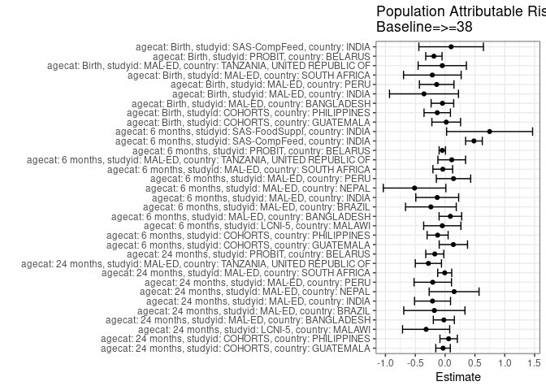

## Results Table

### Parameter: TSM

| agecat | studyid | country | intervention_level | baseline_level | estimate | ci_lower | ci_upper |
| --- | --- | --- | --- | --- | --- | --- | --- |
| Birth | COHORTS | GUATEMALA | >=38 | NA | -1.0769426 | -1.3406520 | -0.8132333 |
| Birth | COHORTS | GUATEMALA | <32 | NA | -1.1861153 | -1.3413381 | -1.0308925 |
| Birth | COHORTS | GUATEMALA | [32-38) | NA | -1.0172144 | -1.2799661 | -0.7544628 |
| Birth | COHORTS | PHILIPPINES | >=38 | NA | -0.5994019 | -0.8255485 | -0.3732553 |
| Birth | COHORTS | PHILIPPINES | <32 | NA | -0.7573930 | -0.8237354 | -0.6910505 |
| Birth | COHORTS | PHILIPPINES | [32-38) | NA | -0.6700998 | -0.8425377 | -0.4976619 |
| Birth | MAL-ED | BANGLADESH | >=38 | NA | -0.9929266 | -1.2652499 | -0.7206033 |
| Birth | MAL-ED | BANGLADESH | <32 | NA | -1.3419306 | -1.7742166 | -0.9096446 |
| Birth | MAL-ED | BANGLADESH | [32-38) | NA | -0.9406730 | -1.2247728 | -0.6565732 |
| Birth | MAL-ED | INDIA | >=38 | NA | -0.5928571 | -1.2084707 | 0.0227564 |
| Birth | MAL-ED | INDIA | <32 | NA | -0.8425000 | -1.5949041 | -0.0900959 |
| Birth | MAL-ED | INDIA | [32-38) | NA | -1.2770000 | -1.9214891 | -0.6325109 |
| Birth | MAL-ED | PERU | >=38 | NA | 0.1936062 | -0.1255796 | 0.5127921 |
| Birth | MAL-ED | PERU | <32 | NA | -0.5202750 | -1.0002895 | -0.0402604 |
| Birth | MAL-ED | PERU | [32-38) | NA | -0.1343797 | -0.4596576 | 0.1908983 |
| Birth | MAL-ED | SOUTH AFRICA | >=38 | NA | 0.2062500 | -0.4416802 | 0.8541802 |
| Birth | MAL-ED | SOUTH AFRICA | <32 | NA | -0.4600000 | -1.7036186 | 0.7836186 |
| Birth | MAL-ED | SOUTH AFRICA | [32-38) | NA | -0.1355556 | -1.1366672 | 0.8655561 |
| Birth | MAL-ED | TANZANIA, UNITED REPUBLIC OF | >=38 | NA | 0.7594118 | 0.2105891 | 1.3082344 |
| Birth | MAL-ED | TANZANIA, UNITED REPUBLIC OF | <32 | NA | 0.4877778 | -0.1646330 | 1.1401886 |
| Birth | MAL-ED | TANZANIA, UNITED REPUBLIC OF | [32-38) | NA | 0.7783333 | 0.3478361 | 1.2088306 |
| Birth | PROBIT | BELARUS | >=38 | NA | -0.9557234 | -1.0912280 | -0.8202189 |
| Birth | PROBIT | BELARUS | <32 | NA | -1.1455968 | -1.3561099 | -0.9350838 |
| Birth | PROBIT | BELARUS | [32-38) | NA | -1.0898892 | -1.3104575 | -0.8693208 |
| Birth | SAS-CompFeed | INDIA | >=38 | NA | -0.7698404 | -1.4769353 | -0.0627456 |
| Birth | SAS-CompFeed | INDIA | <32 | NA | -0.6717842 | -0.8367884 | -0.5067800 |
| Birth | SAS-CompFeed | INDIA | [32-38) | NA | -0.6370333 | -0.8574076 | -0.4166589 |
| 6 months | COHORTS | GUATEMALA | >=38 | NA | 0.0541571 | -0.1976878 | 0.3060020 |
| 6 months | COHORTS | GUATEMALA | <32 | NA | 0.3232070 | 0.1650034 | 0.4814106 |
| 6 months | COHORTS | GUATEMALA | [32-38) | NA | 0.0272545 | -0.2016335 | 0.2561425 |

[output cut: 69 more lines]

### Parameter: E(Y)

| agecat | studyid | country | intervention_level | baseline_level | estimate | ci_lower | ci_upper |
| --- | --- | --- | --- | --- | --- | --- | --- |
| Birth | COHORTS | GUATEMALA | NA | NA | -1.0580408 | -1.1607065 | -0.9553751 |
| Birth | COHORTS | PHILIPPINES | NA | NA | -0.7309760 | -0.7780724 | -0.6838797 |
| Birth | MAL-ED | BANGLADESH | NA | NA | -1.0375000 | -1.2165024 | -0.8584976 |
| Birth | MAL-ED | INDIA | NA | NA | -0.9464000 | -1.3554144 | -0.5373856 |
| Birth | MAL-ED | PERU | NA | NA | 0.0529851 | -0.1628445 | 0.2688147 |
| Birth | MAL-ED | SOUTH AFRICA | NA | NA | -0.0073333 | -0.5181900 | 0.5035233 |
| Birth | MAL-ED | TANZANIA, UNITED REPUBLIC OF | NA | NA | 0.7115909 | 0.4034609 | 1.0197209 |
| Birth | PROBIT | BELARUS | NA | NA | -1.1436672 | -1.3543559 | -0.9329784 |
| Birth | SAS-CompFeed | INDIA | NA | NA | -0.6685468 | -0.8459689 | -0.4911247 |
| 6 months | COHORTS | GUATEMALA | NA | NA | 0.1925914 | 0.1205037 | 0.2646791 |
| 6 months | COHORTS | PHILIPPINES | NA | NA | -0.2878032 | -0.3296319 | -0.2459745 |
| 6 months | LCNI-5 | MALAWI | NA | NA | 0.5060377 | 0.3131397 | 0.6989358 |
| 6 months | MAL-ED | BANGLADESH | NA | NA | -0.1950111 | -0.3575506 | -0.0324716 |
| 6 months | MAL-ED | BRAZIL | NA | NA | 0.9365401 | 0.6541549 | 1.2189253 |
| 6 months | MAL-ED | INDIA | NA | NA | -0.7292288 | -0.8803893 | -0.5780683 |
| 6 months | MAL-ED | NEPAL | NA | NA | 0.1749789 | -0.0644624 | 0.4144202 |
| 6 months | MAL-ED | PERU | NA | NA | 1.0182129 | 0.7827641 | 1.2536616 |
| 6 months | MAL-ED | SOUTH AFRICA | NA | NA | 0.5158052 | 0.2517895 | 0.7798210 |
| 6 months | MAL-ED | TANZANIA, UNITED REPUBLIC OF | NA | NA | 0.5271500 | 0.3177522 | 0.7365478 |
| 6 months | PROBIT | BELARUS | NA | NA | 0.5731698 | 0.5135069 | 0.6328327 |
| 6 months | SAS-CompFeed | INDIA | NA | NA | -0.6641059 | -0.8040033 | -0.5242086 |
| 6 months | SAS-FoodSuppl | INDIA | NA | NA | -1.0121579 | -1.1280429 | -0.8962729 |
| 24 months | COHORTS | GUATEMALA | NA | NA | -0.2760853 | -0.3311930 | -0.2209775 |
| 24 months | COHORTS | PHILIPPINES | NA | NA | -0.6087584 | -0.6459824 | -0.5715345 |
| 24 months | LCNI-5 | MALAWI | NA | NA | -0.1979730 | -0.4244675 | 0.0285215 |
| 24 months | MAL-ED | BANGLADESH | NA | NA | -0.8844702 | -1.0263143 | -0.7426261 |
| 24 months | MAL-ED | BRAZIL | NA | NA | 0.5448101 | 0.2082313 | 0.8813890 |
| 24 months | MAL-ED | INDIA | NA | NA | -0.8968012 | -1.0287307 | -0.7648718 |
| 24 months | MAL-ED | NEPAL | NA | NA | -0.2794304 | -0.4767398 | -0.0821210 |
| 24 months | MAL-ED | PERU | NA | NA | 0.1198207 | -0.0845120 | 0.3241534 |
| 24 months | MAL-ED | SOUTH AFRICA | NA | NA | 0.4414045 | 0.2336389 | 0.6491701 |
| 24 months | MAL-ED | TANZANIA, UNITED REPUBLIC OF | NA | NA | 0.0766500 | -0.1115307 | 0.2648307 |
| 24 months | PROBIT | BELARUS | NA | NA | 0.6963019 | 0.5831245 | 0.8094793 |

### Parameter: ATE

| agecat | studyid | country | intervention_level | baseline_level | estimate | ci_lower | ci_upper |
| --- | --- | --- | --- | --- | --- | --- | --- |
| Birth | COHORTS | GUATEMALA | >=38 | >=38 | 0.0000000 | 0.0000000 | 0.0000000 |
| Birth | COHORTS | GUATEMALA | <32 | >=38 | -0.1091727 | -0.4139333 | 0.1955880 |
| Birth | COHORTS | GUATEMALA | [32-38) | >=38 | 0.0597282 | -0.3104917 | 0.4299481 |
| Birth | COHORTS | PHILIPPINES | >=38 | >=38 | 0.0000000 | 0.0000000 | 0.0000000 |
| Birth | COHORTS | PHILIPPINES | <32 | >=38 | -0.1579911 | -0.3938502 | 0.0778680 |
| Birth | COHORTS | PHILIPPINES | [32-38) | >=38 | -0.0706979 | -0.3552665 | 0.2138707 |
| Birth | MAL-ED | BANGLADESH | >=38 | >=38 | 0.0000000 | 0.0000000 | 0.0000000 |
| Birth | MAL-ED | BANGLADESH | <32 | >=38 | -0.3490040 | -0.8615013 | 0.1634934 |
| Birth | MAL-ED | BANGLADESH | [32-38) | >=38 | 0.0522536 | -0.3421461 | 0.4466533 |
| Birth | MAL-ED | INDIA | >=38 | >=38 | 0.0000000 | 0.0000000 | 0.0000000 |
| Birth | MAL-ED | INDIA | <32 | >=38 | -0.2496429 | -1.2218012 | 0.7225155 |
| Birth | MAL-ED | INDIA | [32-38) | >=38 | -0.6841429 | -1.5754039 | 0.2071182 |
| Birth | MAL-ED | PERU | >=38 | >=38 | 0.0000000 | 0.0000000 | 0.0000000 |
| Birth | MAL-ED | PERU | <32 | >=38 | -0.7138812 | -1.2954766 | -0.1322859 |
| Birth | MAL-ED | PERU | [32-38) | >=38 | -0.3279859 | -0.7862188 | 0.1302469 |
| Birth | MAL-ED | SOUTH AFRICA | >=38 | >=38 | 0.0000000 | 0.0000000 | 0.0000000 |
| Birth | MAL-ED | SOUTH AFRICA | <32 | >=38 | -0.6662500 | -2.0685341 | 0.7360341 |
| Birth | MAL-ED | SOUTH AFRICA | [32-38) | >=38 | -0.3418056 | -1.5342979 | 0.8506868 |
| Birth | MAL-ED | TANZANIA, UNITED REPUBLIC OF | >=38 | >=38 | 0.0000000 | 0.0000000 | 0.0000000 |
| Birth | MAL-ED | TANZANIA, UNITED REPUBLIC OF | <32 | >=38 | -0.2716340 | -1.1241867 | 0.5809187 |
| Birth | MAL-ED | TANZANIA, UNITED REPUBLIC OF | [32-38) | >=38 | 0.0189216 | -0.6785984 | 0.7164416 |
| Birth | PROBIT | BELARUS | >=38 | >=38 | 0.0000000 | 0.0000000 | 0.0000000 |
| Birth | PROBIT | BELARUS | <32 | >=38 | -0.1898734 | -0.3342384 | -0.0455085 |
| Birth | PROBIT | BELARUS | [32-38) | >=38 | -0.1341658 | -0.2770628 | 0.0087313 |
| Birth | SAS-CompFeed | INDIA | >=38 | >=38 | 0.0000000 | 0.0000000 | 0.0000000 |
| Birth | SAS-CompFeed | INDIA | <32 | >=38 | 0.0980562 | -0.4626596 | 0.6587720 |
| Birth | SAS-CompFeed | INDIA | [32-38) | >=38 | 0.1328072 | -0.4240745 | 0.6896888 |
| 6 months | COHORTS | GUATEMALA | >=38 | >=38 | 0.0000000 | 0.0000000 | 0.0000000 |
| 6 months | COHORTS | GUATEMALA | <32 | >=38 | 0.2690499 | -0.0276286 | 0.5657283 |
| 6 months | COHORTS | GUATEMALA | [32-38) | >=38 | -0.0269026 | -0.3670727 | 0.3132674 |

[output cut: 69 more lines]

### Parameter: PAR

| agecat | studyid | country | intervention_level | baseline_level | estimate | ci_lower | ci_upper |
| --- | --- | --- | --- | --- | --- | --- | --- |
| Birth | COHORTS | GUATEMALA | >=38 | NA | 0.0189018 | -0.2214577 | 0.2592614 |
| Birth | COHORTS | PHILIPPINES | >=38 | NA | -0.1315742 | -0.3527903 | 0.0896420 |
| Birth | MAL-ED | BANGLADESH | >=38 | NA | -0.0445734 | -0.2336188 | 0.1444720 |
| Birth | MAL-ED | INDIA | >=38 | NA | -0.3535429 | -0.9315083 | 0.2244226 |
| Birth | MAL-ED | PERU | >=38 | NA | -0.1406212 | -0.4302351 | 0.1489928 |
| Birth | MAL-ED | SOUTH AFRICA | >=38 | NA | -0.2135833 | -0.6962706 | 0.2691039 |
| Birth | MAL-ED | TANZANIA, UNITED REPUBLIC OF | >=38 | NA | -0.0478209 | -0.4520486 | 0.3564069 |
| Birth | PROBIT | BELARUS | >=38 | NA | -0.1879438 | -0.3244949 | -0.0513926 |
| Birth | SAS-CompFeed | INDIA | >=38 | NA | 0.1012937 | -0.4395959 | 0.6421832 |
| 6 months | COHORTS | GUATEMALA | >=38 | NA | 0.1384343 | -0.0991220 | 0.3759905 |
| 6 months | COHORTS | PHILIPPINES | >=38 | NA | -0.1254071 | -0.3015892 | 0.0507749 |
| 6 months | LCNI-5 | MALAWI | >=38 | NA | -0.0467985 | -0.3590297 | 0.2654327 |
| 6 months | MAL-ED | BANGLADESH | >=38 | NA | 0.0887187 | -0.1005985 | 0.2780359 |
| 6 months | MAL-ED | BRAZIL | >=38 | NA | -0.2380802 | -0.6629523 | 0.1867919 |
| 6 months | MAL-ED | INDIA | >=38 | NA | -0.1317965 | -0.4909279 | 0.2273350 |
| 6 months | MAL-ED | NEPAL | >=38 | NA | -0.5115624 | -1.0358196 | 0.0126948 |
| 6 months | MAL-ED | PERU | >=38 | NA | 0.1408121 | -0.1472260 | 0.4288503 |
| 6 months | MAL-ED | SOUTH AFRICA | >=38 | NA | -0.0388302 | -0.2037095 | 0.1260492 |
| 6 months | MAL-ED | TANZANIA, UNITED REPUBLIC OF | >=38 | NA | 0.1111108 | -0.1205560 | 0.3427776 |
| 6 months | PROBIT | BELARUS | >=38 | NA | -0.0465130 | -0.1003214 | 0.0072954 |
| 6 months | SAS-CompFeed | INDIA | >=38 | NA | 0.4834747 | 0.3435166 | 0.6234327 |
| 6 months | SAS-FoodSuppl | INDIA | >=38 | NA | 0.7457222 | 0.0253341 | 1.4661103 |
| 24 months | COHORTS | GUATEMALA | >=38 | NA | -0.0343229 | -0.1557312 | 0.0870855 |
| 24 months | COHORTS | PHILIPPINES | >=38 | NA | 0.0594574 | -0.0861463 | 0.2050611 |
| 24 months | LCNI-5 | MALAWI | >=38 | NA | -0.3179379 | -0.7128913 | 0.0770156 |
| 24 months | MAL-ED | BANGLADESH | >=38 | NA | -0.0210166 | -0.1970474 | 0.1550141 |
| 24 months | MAL-ED | BRAZIL | >=38 | NA | -0.1798889 | -0.6926052 | 0.3328275 |
| 24 months | MAL-ED | INDIA | >=38 | NA | -0.2103002 | -0.5118068 | 0.0912064 |
| 24 months | MAL-ED | NEPAL | >=38 | NA | 0.1511319 | -0.2668314 | 0.5690952 |
| 24 months | MAL-ED | PERU | >=38 | NA | -0.2065016 | -0.5202928 | 0.1072896 |
| 24 months | MAL-ED | SOUTH AFRICA | >=38 | NA | -0.0064929 | -0.1236499 | 0.1106640 |
| 24 months | MAL-ED | TANZANIA, UNITED REPUBLIC OF | >=38 | NA | -0.2797506 | -0.4992206 | -0.0602807 |
| 24 months | PROBIT | BELARUS | >=38 | NA | -0.1728731 | -0.3241551 | -0.0215911 |